# TDF Velogames Daily Update

### Race Results - Stage 21

Many of you no doubt already know the result, but here’s the non-spoiler 5min highlight clip on Youtube:  
https://youtu.be/5EJUjd4WV-A  
Dutch sprinter Dylan Groenewegen provided an upset victory over the more established fast-man favourites on the Champs-Élysées ahead of André Greipel, the biggest win of his career. Edvald Boasson Hagen finished third. All the jersey winnners arrived at the finish line safely in the pack, with Chris Froome taking his fourth Tour De France win.  
Results on cycling news:  
http://www.cyclingnews.com/giro-ditalia/stage-21/results/

| Stage Result |
| --- |

|  | # | Rider Name (Country) Team | Result |
| --- | --- | --- | --- |
| 2 | 1 | Dylan Groenewegen (Ned) Team LottoNl-Jumbo | 2:25:39 |
| 3 | 2 | André Greipel (Ger) Lotto Soudal |  |
| 4 | 3 | Edvald Boasson Hagen (Nor) Dimension Data |  |
| 5 | 4 | Nacer Bouhanni (Fra) Cofidis, Solutions Credits |  |
| 6 | 5 | Alexander Kristoff (Nor) Katusha-Alpecin |  |
| 7 | 6 | Borut Bozic (Slo) Bahrain-Merida |  |
| 8 | 7 | Davide Cimolai (Ita) FDJ |  |
| 9 | 8 | Pierre Luc Perichon (Fra) Team Fortuneo - Oscaro |  |
| 10 | 9 | Rüdiger Selig (Ger) Bora-Hansgrohe |  |
| 11 | 10 | Daniele Bennati (Ita) Movistar Team |  |

### Velogames Results - 4051 Rouleurs - Final

It’s worth pointing out the method used by Velogames for calculating points after the final stage. Velogames awards points in the normal manner for Stage 21, but then awards points using an imaginary Stage 22 for Bonus Points based on rider finishing positions in accordance with the game rules:  
https://www.velogames.com/tour-de-france/2017/scores.php

#### Highest Scoring Riders

##### for Stage 21, from our teams

The riders earning maximum points for Stage 21, and the teams that picked them were:

| rider | stage | Total | Selected by |
| --- | --- | --- | --- |
| André Greipel | 21 | 156 | Champagne Taste |
| Nacer Bouhanni | 21 | 100 | Oldies |
| Alexander Kristoff | 21 | 83 | Champagne Taste,The Paranoid Androids |
| Mikel Landa | 21 | 38 | Saddle Sores,2 seconds faster,Top Nobs,gagnants |
| Christopher Froome | 21 | 37 | Wilston Wippets,Dick`s Dodgers,The Ron Burgandy All Stars,Ferris Wheel,TDF 101,Top Nobs |
| Michael Matthews | 21 | 35 | Brake Rub Regression,Ferris Wheel,Bianchi |
| Mikel Nieve | 21 | 27 | Saddle Sores |
| Romain Bardet | 21 | 26 | Legless,Brake Rub Regression,Wilston Wippets,Dick`s Dodgers,The Ron Burgandy All Stars,Gruppetto Greats ,Little Crookies |
| Marcus Burghardt | 21 | 25 | The Ron Burgandy All Stars |
| Rigoberto Uran | 21 | 22 | Saddle Sores,The Paranoid Androids ,Maluka |

#### Highest Scoring Riders

##### for Stage 22, from our teams

The riders earning maximum points from the Bonus Points on offer (Stage 22), and the teams that picked them were:

| rider | stage | Total | Selected by |
| --- | --- | --- | --- |
| Christopher Froome | 22 | 595 | Wilston Wippets,Dick`s Dodgers,The Ron Burgandy All Stars,Ferris Wheel,TDF 101,Top Nobs |
| Romain Bardet | 22 | 410 | Legless,Brake Rub Regression,Wilston Wippets,Dick`s Dodgers,The Ron Burgandy All Stars,Gruppetto Greats ,Little Crookies |
| Rigoberto Uran | 22 | 410 | Saddle Sores,The Paranoid Androids ,Maluka |
| Mikel Landa | 22 | 360 | Saddle Sores,2 seconds faster,Top Nobs,gagnants |
| Fabio Aru | 22 | 260 | Champagne Taste,Ferris Wheel,Bianchi,gagnants,Little Crookies |
| Warren Barguil | 22 | 240 | Dick`s Dodgers,Chamois Shakers,Gruppetto Greats |
| Daniel Martin | 22 | 225 | Lanterne Rouge |
| Simon Yates | 22 | 205 | Brake Rub Regression,2 seconds faster,Lanterne Rouge,Itchy Nads,The Paranoid Androids ,gagnants,Little Crookies |
| Louis Meintjes | 22 | 180 | Gears n Beers,Oldies,Lanterne Rouge |
| Mikel Nieve | 22 | 140 | Saddle Sores |

The chart below demonstrates what a difference Romain Bardet made in the Velogames comp. Nario was clearly a disappointment, costing a lot an not delivering on that investment. Porte and Sagan languish in the extremely poor value section thanks to their early departure. Uran and Matthews stand out as being excellent value.

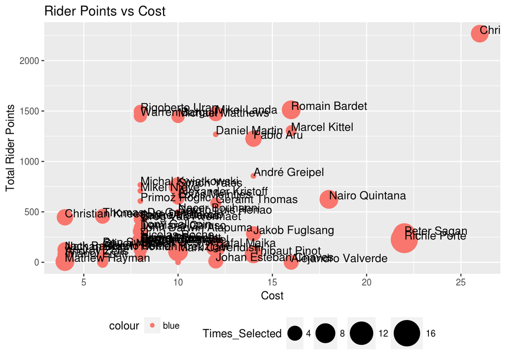

#### Top scoring teams for stage

Points from Stage 21:

So Britt Groom cleaned up stage 21.

| team | directeur | Stage_Points |
| --- | --- | --- |
| Champagne Taste | Britt Groom | 271 |
| The Paranoid Androids | Mick Groom | 133 |
| Oldies | Jim Martin | 118 |
| Dick`s Dodgers | Rich Johnston | 107 |
| The Ron Burgandy All Stars | Steve Kelsall | 106 |
| Top Nobs | Chris Forini | 104 |
| Ferris Wheel | Jeff Beehler | 102 |
| gagnants | mark fitzpatrick | 98 |
| Saddle Sores | Brett Jensen | 97 |
| Brake Rub Regression | Simon Lyons | 93 |
| Wilston Wippets | Peter Howes | 86 |
| Lanterne Rouge | Andrew Carroll | 82 |
| Bianchi | Jamie Forster | 80 |
| Gruppetto Greats | David Pink | 70 |
| Little Crookies | Crooky | 66 |
| 2 seconds faster | Dean McBeath | 63 |
| Thistles | Simon Scott | 60 |
| Legless | David Leggett | 56 |
| TDF 101 | Luke Jardine | 56 |
| Itchy Nads | Dan | 53 |
| Gears n Beers | Chris Fraser | 45 |
| Maluka | MurrayMaluka | 42 |
| The Smiling Assassins | Andrew Glutz | 32 |
| Chamois Shakers | Matt | 31 |
| Opto`s TDF Weapons | Mark Hinds | 17 |

Bonus Points (Stage 22):

| team | directeur | Stage_Points |
| --- | --- | --- |
| Dick`s Dodgers | Rich Johnston | 1335 |
| Ferris Wheel | Jeff Beehler | 1110 |
| Wilston Wippets | Peter Howes | 1110 |
| The Ron Burgandy All Stars | Steve Kelsall | 1040 |
| Top Nobs | Chris Forini | 1010 |
| Little Crookies | Crooky | 960 |
| Saddle Sores | Brett Jensen | 950 |
| gagnants | mark fitzpatrick | 945 |
| The Paranoid Androids | Mick Groom | 850 |
| Gruppetto Greats | David Pink | 800 |
| Brake Rub Regression | Simon Lyons | 795 |
| TDF 101 | Luke Jardine | 740 |
| 2 seconds faster | Dean McBeath | 725 |
| Lanterne Rouge | Andrew Carroll | 695 |
| Champagne Taste | Britt Groom | 585 |
| Maluka | MurrayMaluka | 550 |
| Bianchi | Jamie Forster | 535 |
| Legless | David Leggett | 460 |
| Chamois Shakers | Matt | 395 |
| Gears n Beers | Chris Fraser | 330 |
| Thistles | Simon Scott | 300 |
| Itchy Nads | Dan | 255 |
| Oldies | Jim Martin | 230 |
| Opto`s TDF Weapons | Mark Hinds | 195 |
| The Smiling Assassins | Andrew Glutz | 165 |

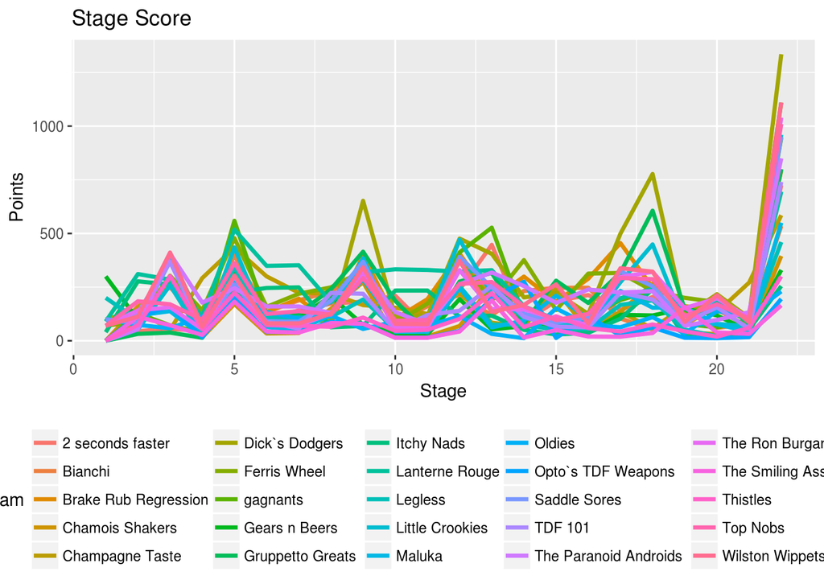

| Team | Total |
| --- | --- |
| Dick`s Dodgers | 5275 |
| Lanterne Rouge | 4994 |
| Ferris Wheel | 4711 |
| Brake Rub Regression | 4381 |
| The Paranoid Androids | 3882 |
| Wilston Wippets | 3813 |
| Gruppetto Greats | 3758 |
| Saddle Sores | 3697 |
| Champagne Taste | 3641 |
| Top Nobs | 3640 |
| gagnants | 3586 |
| Bianchi | 3506 |
| Little Crookies | 3392 |
| The Ron Burgandy All Stars | 3309 |
| 2 seconds faster | 3158 |
| TDF 101 | 2953 |
| Gears n Beers | 2741 |
| Itchy Nads | 2729 |
| Legless | 2713 |
| Maluka | 2627 |
| Chamois Shakers | 2308 |
| Oldies | 1958 |
| Thistles | 1868 |
| Opto`s TDF Weapons | 1548 |
| The Smiling Assassins | 1263 |

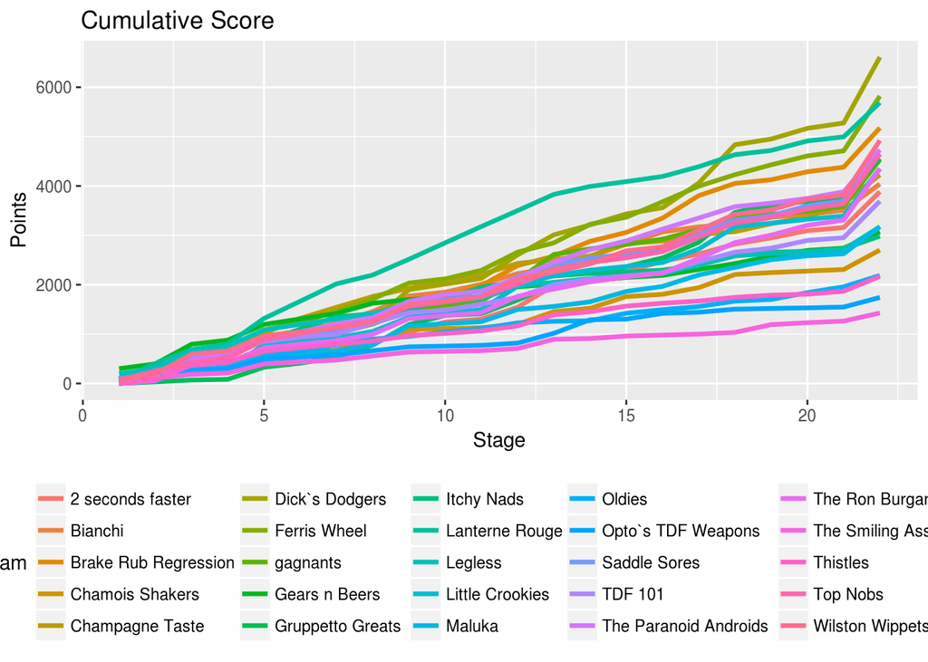

### Team Cross Reference

Here’s a more useful version of the table I sent out with the Stage 1 update. As well as identifying which riders have been selected the most times in our Velogames squads, it now includes which teams have each rider. It should be helpful in determining which of your squad are essentially a null contribution given they are matched in one or more other teams.

| rider | Times_Selected | Andrew Carroll | Andrew Glutz | Brett Jensen | Britt Groom | Chris Forini | Chris Fraser | Crooky | Dan | David Leggett | David Pink | Dean McBeath | Jamie Forster | Jeff Beehler | Jim Martin | Luke Jardine | mark fitzpatrick | Mark Hinds | Matt | Mick Groom | MurrayMaluka | Peter Howes | Rich Johnston | Simon Lyons | Simon Scott | Steve Kelsall |
| --- | --- | --- | --- | --- | --- | --- | --- | --- | --- | --- | --- | --- | --- | --- | --- | --- | --- | --- | --- | --- | --- | --- | --- | --- | --- | --- |
| Richie Porte | 17 | Yes | Yes | Yes | Yes | Yes | Yes |  | Yes | Yes | Yes |  | Yes |  | Yes |  | Yes | Yes | Yes |  | Yes |  |  | Yes | Yes |  |
| Peter Sagan | 11 |  |  | Yes |  |  | Yes | Yes | Yes | Yes |  |  |  |  |  | Yes |  |  | Yes | Yes |  | Yes | Yes |  | Yes |  |
| Mark Cavendish | 8 |  | Yes |  |  | Yes |  |  |  |  |  |  | Yes |  |  |  | Yes | Yes | Yes |  | Yes |  |  |  |  | Yes |
| Rafal Majka | 8 |  |  |  | Yes |  | Yes |  |  |  |  |  |  | Yes | Yes |  |  |  |  | Yes | Yes | Yes |  |  |  | Yes |
| Mathew Hayman | 7 | Yes | Yes |  |  |  |  | Yes |  | Yes |  |  |  |  |  | Yes |  |  |  | Yes |  |  |  |  |  | Yes |
| Nairo Quintana | 7 |  | Yes |  |  |  |  |  |  |  |  | Yes |  |  |  | Yes | Yes | Yes |  | Yes |  |  |  |  | Yes |  |
| Romain Bardet | 7 |  |  |  |  |  |  | Yes |  | Yes | Yes |  |  |  |  |  |  |  |  |  |  | Yes | Yes | Yes |  | Yes |
| Simon Yates | 7 | Yes |  |  |  |  |  | Yes | Yes |  |  | Yes |  |  |  |  | Yes |  |  | Yes |  |  |  | Yes |  |  |
| Christopher Froome | 6 |  |  |  |  | Yes |  |  |  |  |  |  |  | Yes |  | Yes |  |  |  |  |  | Yes | Yes |  |  | Yes |
| Thibaut Pinot | 6 |  | Yes |  |  |  |  |  |  |  | Yes | Yes |  |  |  |  |  |  |  |  | Yes |  |  |  | Yes | Yes |
| Tony Martin | 6 |  |  | Yes | Yes |  | Yes |  |  |  |  | Yes |  |  | Yes |  |  |  |  |  |  |  |  | Yes |  |  |
| Christian Knees | 5 | Yes |  |  |  |  | Yes |  |  | Yes |  |  |  |  |  |  |  |  |  |  |  |  | Yes |  | Yes |  |
| Fabio Aru | 5 |  |  |  | Yes |  |  | Yes |  |  |  |  | Yes | Yes |  |  | Yes |  |  |  |  |  |  |  |  |  |
| Alejandro Valverde | 4 |  |  |  |  |  |  | Yes |  |  |  |  |  | Yes | Yes |  |  | Yes |  |  |  |  |  |  |  |  |
| Andrey Zeits | 4 |  |  |  |  |  |  |  |  | Yes |  |  |  |  |  |  | Yes |  |  |  |  |  |  | Yes | Yes |  |
| Jack Bauer | 4 |  |  |  |  |  |  | Yes |  |  |  |  |  |  | Yes |  |  |  |  |  |  | Yes | Yes |  |  |  |
| Jakob Fuglsang | 4 | Yes |  |  |  |  |  |  |  |  |  |  | Yes |  |  |  |  |  |  |  | Yes |  |  | Yes |  |  |
| Johan Esteban Chaves | 4 |  | Yes |  |  |  |  |  |  | Yes |  | Yes |  |  |  |  |  |  | Yes |  |  |  |  |  |  |  |
| John Darwin Atapuma | 4 |  |  |  |  |  |  | Yes | Yes |  | Yes |  |  |  |  |  |  |  |  |  |  |  | Yes |  |  |  |
| Mikel Landa | 4 |  |  | Yes |  | Yes |  |  |  |  |  | Yes |  |  |  |  | Yes |  |  |  |  |  |  |  |  |  |
| Sylvain Chavanel | 4 |  | Yes |  |  |  |  |  |  |  | Yes |  | Yes |  |  |  |  |  |  |  |  |  |  |  |  | Yes |
| Thomas De Gendt | 4 |  |  |  | Yes |  | Yes |  |  |  |  |  |  | Yes |  |  |  |  |  |  | Yes |  |  |  |  |  |
| Bauke Mollema | 3 |  |  |  | Yes |  |  |  |  |  |  |  | Yes |  |  |  |  |  |  |  |  | Yes |  |  |  |  |
| Imanol Erviti | 3 |  |  |  |  |  |  |  | Yes |  |  |  |  |  |  |  | Yes |  |  |  |  |  |  |  | Yes |  |
| Louis Meintjes | 3 | Yes |  |  |  |  | Yes |  |  |  |  |  |  |  | Yes |  |  |  |  |  |  |  |  |  |  |  |
| Michael Matthews | 3 |  |  |  |  |  |  |  |  |  |  |  | Yes | Yes |  |  |  |  |  |  |  |  |  | Yes |  |  |
| Nicolas Roche | 3 |  |  |  |  |  |  |  |  |  | Yes | Yes |  |  |  |  |  |  | Yes |  |  |  |  |  |  |  |
| Rigoberto Uran | 3 |  |  | Yes |  |  |  |  |  |  |  |  |  |  |  |  |  |  |  | Yes | Yes |  |  |  |  |  |
| Roman Kreuziger | 3 |  |  | Yes |  |  |  |  |  |  | Yes |  | Yes |  |  |  |  |  |  |  |  |  |  |  |  |  |
| Tony Gallopin | 3 |  |  |  |  |  |  |  |  |  |  |  |  |  | Yes |  |  |  |  | Yes | Yes |  |  |  |  |  |
| Warren Barguil | 3 |  |  |  |  |  |  |  |  |  | Yes |  |  |  |  |  |  |  | Yes |  |  |  | Yes |  |  |  |
| Adam Hansen | 2 |  |  |  |  | Yes |  |  |  |  |  |  |  |  |  |  |  |  |  |  | Yes |  |  |  |  |  |
| Alexander Kristoff | 2 |  |  |  | Yes |  |  |  |  |  |  |  |  |  |  |  |  |  |  | Yes |  |  |  |  |  |  |
| Damiano Caruso | 2 |  |  |  |  |  |  |  |  |  |  |  |  |  |  |  |  |  | Yes |  |  |  |  |  | Yes |  |
| Geraint Thomas | 2 |  |  |  |  |  | Yes |  |  | Yes |  |  |  |  |  |  |  |  |  |  |  |  |  |  |  |  |
| Greg Van Avermaet | 2 |  |  |  |  |  |  |  |  |  |  |  |  |  |  |  |  | Yes |  | Yes |  |  |  |  |  |  |
| John Degenkolb | 2 |  |  |  |  |  |  |  |  |  | Yes | Yes |  |  |  |  |  |  |  |  |  |  |  |  |  |  |
| Lars Bak | 2 |  |  | Yes |  |  |  |  |  |  |  |  | Yes |  |  |  |  |  |  |  |  |  |  |  |  |  |
| Luke Durbridge | 2 |  |  |  |  |  |  |  |  |  |  |  |  |  |  |  | Yes |  |  |  |  |  |  |  |  | Yes |
| Marcel Kittel | 2 | Yes |  |  |  |  |  |  | Yes |  |  |  |  |  |  |  |  |  |  |  |  |  |  |  |  |  |
| Mark Renshaw | 2 |  |  |  | Yes | Yes |  |  |  |  |  |  |  |  |  |  |  |  |  |  |  |  |  |  |  |  |
| Michael Albasini | 2 |  | Yes |  |  |  |  |  |  |  |  | Yes |  |  |  |  |  |  |  |  |  |  |  |  |  |  |
| Robert Wagner | 2 |  |  |  |  |  |  |  |  | Yes |  |  |  |  |  | Yes |  |  |  |  |  |  |  |  |  |  |
| Thomas Voeckler | 2 |  |  |  |  |  |  |  |  |  |  |  |  |  |  |  |  | Yes | Yes |  |  |  |  |  |  |  |
| Alberto Bettiol | 1 |  |  | Yes |  |  |  |  |  |  |  |  |  |  |  |  |  |  |  |  |  |  |  |  |  |  |
| Albert Timmer | 1 |  |  |  |  |  |  |  |  |  |  |  |  |  |  |  |  |  |  |  |  |  |  |  | Yes |  |
| André Greipel | 1 |  |  |  | Yes |  |  |  |  |  |  |  |  |  |  |  |  |  |  |  |  |  |  |  |  |  |
| Ben Swift | 1 |  |  |  |  |  |  |  |  |  |  |  |  |  |  | Yes |  |  |  |  |  |  |  |  |  |  |
| Bernhard Eisel | 1 |  |  |  |  | Yes |  |  |  |  |  |  |  |  |  |  |  |  |  |  |  |  |  |  |  |  |
| Carlos Betancur | 1 |  |  |  |  |  |  |  |  |  |  |  |  |  |  |  |  | Yes |  |  |  |  |  |  |  |  |
| Daniel Martin | 1 | Yes |  |  |  |  |  |  |  |  |  |  |  |  |  |  |  |  |  |  |  |  |  |  |  |  |
| Daniel Navarro | 1 |  |  |  |  |  |  |  |  |  |  |  |  |  |  | Yes |  |  |  |  |  |  |  |  |  |  |
| Frederik Backaert | 1 |  |  |  |  |  |  |  |  |  |  |  |  |  |  | Yes |  |  |  |  |  |  |  |  |  |  |
| George Bennett | 1 |  |  |  |  |  |  |  |  |  |  |  |  |  |  |  |  |  |  |  |  |  | Yes |  |  |  |
| Ion Izagirre | 1 |  |  |  |  |  |  |  |  |  |  |  |  |  | Yes |  |  |  |  |  |  |  |  |  |  |  |
| Jay McCarthy | 1 |  |  |  |  |  |  |  |  |  |  |  |  |  |  |  |  | Yes |  |  |  |  |  |  |  |  |
| Juraj Sagan | 1 |  |  |  |  |  |  |  |  |  |  |  |  |  |  |  |  |  | Yes |  |  |  |  |  |  |  |
| Koen De Kort | 1 |  |  |  |  |  | Yes |  |  |  |  |  |  |  |  |  |  |  |  |  |  |  |  |  |  |  |
| Laurent Pichon | 1 |  |  |  |  |  |  |  |  |  |  |  |  |  |  |  |  |  |  |  |  | Yes |  |  |  |  |
| Marcus Burghardt | 1 |  |  |  |  |  |  |  |  |  |  |  |  |  |  |  |  |  |  |  |  |  |  |  |  | Yes |
| Michal Kwiatkowski | 1 | Yes |  |  |  |  |  |  |  |  |  |  |  |  |  |  |  |  |  |  |  |  |  |  |  |  |
| Mikel Nieve | 1 |  |  | Yes |  |  |  |  |  |  |  |  |  |  |  |  |  |  |  |  |  |  |  |  |  |  |
| Mike Teunissen | 1 |  |  |  |  |  |  |  |  |  |  |  |  | Yes |  |  |  |  |  |  |  |  |  |  |  |  |
| Nacer Bouhanni | 1 |  |  |  |  |  |  |  |  |  |  |  |  |  | Yes |  |  |  |  |  |  |  |  |  |  |  |
| Nathan Brown | 1 |  | Yes |  |  |  |  |  |  |  |  |  |  |  |  |  |  |  |  |  |  |  |  |  |  |  |
| Nils Politt | 1 |  |  |  |  |  |  |  |  |  |  |  |  |  |  |  |  |  |  |  |  | Yes |  |  |  |  |
| Oliver Naesen | 1 |  |  |  |  |  |  | Yes |  |  |  |  |  |  |  |  |  |  |  |  |  |  |  |  |  |  |
| Olivier Le Gac | 1 |  |  |  |  |  |  |  |  |  |  |  |  |  |  |  |  |  |  |  |  |  | Yes |  |  |  |
| Paul Martens | 1 |  |  |  |  |  |  |  | Yes |  |  |  |  |  |  |  |  |  |  |  |  |  |  |  |  |  |
| Pierre Rolland | 1 |  |  |  |  |  |  |  | Yes |  |  |  |  |  |  |  |  |  |  |  |  |  |  |  |  |  |
| Primož Roglic | 1 |  |  |  |  |  |  |  |  |  |  |  |  |  |  |  |  |  |  |  |  |  |  | Yes |  |  |
| Robert Gesink | 1 |  |  |  |  |  |  |  |  |  |  |  |  |  |  | Yes |  |  |  |  |  |  |  |  |  |  |
| Scott Thwaites | 1 |  |  |  |  | Yes |  |  |  |  |  |  |  |  |  |  |  |  |  |  |  |  |  |  |  |  |
| Serge Pauwels | 1 |  |  |  |  |  |  |  |  |  |  |  |  | Yes |  |  |  |  |  |  |  |  |  |  |  |  |
| Sergio Luis Henao | 1 |  |  |  |  | Yes |  |  |  |  |  |  |  |  |  |  |  |  |  |  |  |  |  |  |  |  |
| Simon Clarke | 1 |  |  |  |  |  |  |  |  |  |  |  |  |  |  |  |  | Yes |  |  |  |  |  |  |  |  |
| Stephen Cummings | 1 |  |  |  |  |  |  |  |  |  |  |  |  |  |  |  |  |  |  |  |  |  |  | Yes |  |  |
| Thomas Degand | 1 |  |  |  |  |  |  |  | Yes |  |  |  |  |  |  |  |  |  |  |  |  |  |  |  |  |  |
| Timo Roosen | 1 |  |  |  |  |  |  |  |  |  |  |  |  |  |  |  |  |  |  |  |  | Yes |  |  |  |  |
| Tsgabu Grmay | 1 |  |  |  |  |  |  |  |  |  |  |  |  | Yes |  |  |  |  |  |  |  |  |  |  |  |  |